# Relación entre el ejercicio, alimentación y rendimiento académico en los estudiantes de UTEC.

7 Abril, 2023

# 1 Introducción

## 1.1 Relevancia

Diversos estudios han demostrado de manera consistente los efectos positivos del ejercicio regular en la capacidad cognitiva, la memoria, la concentración y la atención, así como en la reducción del estrés y la ansiedad. Asimismo, una alimentación equilibrada y saludable proporciona a los estudiantes los nutrientes y la energía necesarios para un adecuado aprendizaje y concentración. En nuestro estudio estadístico, nos proponemos determinar el grado de influencia de estos dos factores en el rendimiento académico de los estudiantes de UTEC. Además, a través de los datos recolectados, podremos conocer los hábitos alimenticios y de ejercicio físico de los alumnos. Dependiendo de los resultados obtenidos, incluso podríamos identificar posibles riesgos de salud futuros en los estudiantes.

**Objetivo general:**

Analizar la relación entre el ejercicio, alimentación y rendimiento académico en los estudiantes de UTEC.

**Objetivos específicos:**

-Identificar el nivel de actividad física y tipo de actividad predominante en los alumnos de UTEC.

-Identificar el tipo de alimentación en los alumnos de UTEC.

-Determinar una posible relación entre la alimentación, el ejercicio y las calificaciones académicas.

-Identificar posibles riesgos de salud en los estudiantes en base a los resultados obtenidos

-Relacionar el nivel de actividad física con el rendimiento académico.

-Analizar si el consumo de diferentes nutrientes (proteínas, vegetales o frutas, grasas, lácteos, cereales o azúcares) se asocia con el rendimiento académico.

# 2 Datos

```r
dat <- read_csv("Datos.csv")
```

## 2.1 Recolección de datos

Los datos serán recolectados a través de distribución (personal y virtual) de formularios realizados con Google Forms, herramienta que permite visualizar los datos recolectados a través de una interfaz amigable. También permite la descarga de los mismos en un archivo “coma separated values”(.csv).

El formulario fue configurado para limitar una respuesta por persona y solo se puede llenar una vez. Además, los encuestados deben poseer un correo administrado por UTEC para así verificar que fueran alumnos de la universidad. No se recolectaron datos sensibles en la encuesta por no tener relevancia para el estudio, tales como el correo, nombre, código de alumno, etc.

## 2.2 Población, muestra y muestreo

**Población:** Estudiantes de la UTEC

**Muestreo:** La técnica utilizada fue una selección simple al azar. Solicitamos llenar la encuesta a estudiantes de la UTEC en diferentes horarios y lugares de la universidad. También solicitamos que algunos de ellos reenvíen la encuesta por redes sociales a sus compañeros de la universidad, logrando así generar una muestra representativa.

## 2.3 Variables

**Generales**

| Pregunta | Nombre de la Variable | Tipo de Variable | Restricciones |
| --- | --- | --- | --- |
| ¿Cuál es tu edad? | edad | Numérica Discreta | Números entre 16 y 29 |
| ¿Cuál es tu peso? (En kilogramos) | peso | Numérica Continua | Números entre 28.5 y 150 |
| ¿Cuál es tu estatura? (en metros) | estatura | Numérica Continua | Números entre 1.30 y 2.40 |
| ¿Que tipo de alimentos consumes principalmente? | alim_principal | Categórica Nominal | Alimentos procesados o alimentos no procesados |
| ¿Realizas actividad física? | act_fisica | Categórica Nominal | Sí o no |
| ¿En qué ciclo te encuentras ahora mismo? | ciclo | Categórica Ordinal | Del primer al décimo ciclo |

Dependiendo de lo que seleccione en algunas preguntas, se le añadirán otras, caso contrario seguirá con las generales.

**Si selecciona “alimentos no procesados”:**

| Pregunta | Nombre de la Variable | Tipo de Variable | Restricciones |
| --- | --- | --- | --- |
| ¿Con qué frecuencia comes proteínas? | proteinas | Categórica Ordinal | De 1 vez por semana hasta 7 veces por semana |
| ¿Con qué frecuencia comes frutas y vegetales? | veg_frut | Categórica Ordinal | De 1 vez por semana hasta 7 veces por semana |
| ¿Con qué frecuencia comes grasas y aceites? | gras_aceit | Categórica Ordinal | De 1 vez por semana hasta 7 veces por semana |
| ¿Con qué frecuencia comes lácteos? | lacteos | Categórica Ordinal | De 1 vez por semana hasta 7 veces por semana |
| ¿Con qué frecuencia comes cereales y granos? | cere_gran | Categórica Ordinal | De 1 vez por semana hasta 7 veces por semana |
| ¿Con qué frecuencia comes azúcares y dulces? | azuc_dul | Categórica Ordinal | De 1 vez por semana hasta 7 veces por semana |

**Si selecciona “si realizo actividad física”:**

| Pregunta | Nombre de la Variable | Tipo de Variable | Restricciones |
| --- | --- | --- | --- |
| ¿Qué tipo de actividad física realizas? | tipo_act | Categórica Nominal | Fútbol, Básquet, Voley, Natación, Tenis, Gimnasia, Gimnasio/Calistenia/Crossfit, Artes Marciales, Running, Ciclismo, Otros |
| ¿Con qué frecuencia realizas la/las actividades? | frec_act | Categórica Ordinal | 1 vez por semana, 2/3 veces por semana, 4/5 veces por semana, 6/7 veces por semana |
| En general ¿cuánto dura tu actividad física? | tiem_act | Numérica Continua | Valor en formato horas/minutos/segundos |

**Si selecciona una opción diferente a primer ciclo:**

| Pregunta | Nombre de la Variable | Tipo de Variable | Restricciones |
| --- | --- | --- | --- |
| ¿En cuál de estas secciones te encuentras actualmente? | clasificacion | Categórica Ordinal | Décimo superior, Quinto superior, Tercio Superior, Medio superior, Ninguno de los anteriores |

## 2.4 Limpieza de Datos

**Renombramiento**

Primero, con este comando renombraremos las columnas (variables) de la tabla

```r
colnames(datos) <- c("edad", "peso", "estatura", "alim_principal", "proteinas", "veg_frut", "gras_aceit", "lacteos", "cere_gran", "azuc_dul", "act_fisica", "tipo_act", "frec_act", "tiem_act", "ciclo", "clasificacion")
```

**Cambio de tipo de dato**

Luego, verificamos cuál es el tipo que posee cada variable

```r
str(datos)
```

```
## tibble [181 x 16] (S3: tbl_df/tbl/data.frame)
##  $ edad          : num [1:181] 18 18 18 18 18 18 18 18 18 18 ...
##  $ peso          : num [1:181] 76 75 51 67.5 76 74 56 98 104 85 ...
##  $ estatura      : num [1:181] 1.77 1.85 1.72 1.79 1.77 1.83 1.64 1.7 1.8 1.75 ...
##  $ alim_principal: chr [1:181] "No procesados (Comida Casera, Menú, Cafetería, etc.)" "No procesados (Comida Casera, Menú, Cafetería, etc.)" "No procesados (Comida Casera, Menú, Cafetería, etc.)" "No procesados (Comida Casera, Menú, Cafetería, etc.)" ...
##  $ proteinas     : chr [1:181] "6 veces por semana" "7 veces por semana" "7 veces por semana" "7 veces por semana" ...
##  $ veg_frut      : chr [1:181] "4 veces por semana" "7 veces por semana" "7 veces por semana" "5 veces por semana" ...
##  $ gras_aceit    : chr [1:181] "2 veces por semana" "5 veces por semana" "7 veces por semana" "3 veces por semana" ...
##  $ lacteos       : chr [1:181] "5 veces por semana" "7 veces por semana" "6 veces por semana" "5 veces por semana" ...
##  $ cere_gran     : chr [1:181] "6 veces por semana" "4 veces por semana" "7 veces por semana" "4 veces por semana" ...
##  $ azuc_dul      : chr [1:181] "2 veces por semana" "3 veces por semana" "4 veces por semana" "2 veces por semana" ...
##  $ act_fisica    : chr [1:181] "Sí" "Sí" "No" "Sí" ...
##  $ tipo_act      : chr [1:181] "Tenis, Gimnasio/Calistenia/Crossfit, Artes Marciales, Running, Ciclismo" "Básquet, Gimnasio/Calistenia/Crossfit" NA "Gimnasio/Calistenia/Crossfit" ...
##  $ frec_act      : chr [1:181] "4/5 veces por semana" "4/5 veces por semana" NA "4/5 veces por semana" ...
##  $ tiem_act      : 'hms' num [1:181] 02:00:00 01:30:00 NA 02:00:00 ...
##   ..- attr(*, "units")= chr "secs"
##  $ ciclo         : chr [1:181] "Tercer Ciclo" "Tercer Ciclo" "Tercer Ciclo" "Tercer Ciclo" ...
##  $ clasificacion : chr [1:181] "1.Décimo superior" "3.Tercio superior" "3.Tercio superior" "2.Quinto superior" ...
```

La variable edad es numérica discreta, pero está especificado como tipo num. Las variables numéricas discretas deberían ser int. Se cambia con el siguiente código

```r
datos$edad <- as.integer(datos$edad)
```

```r
datos$tiem_act <- as.numeric(as.period(datos$tiem_act, unit = "seconds"))
```

**Limitación y cambio de datos (post-recolección)**

- Al cambiar el tipo de dato de la edad, si en algún punto de la actualización de los datos alguien coloca un número decimal, se truncará automáticamente. El máximo y mínimo es limitado en el formulario de Google.
- Redondearemos a dos decimales cualquier dato con más de dos que pertenezca al peso y/o estatura. El máximo y mínimo es limitado en el formulario de Google.

```r
datos$peso <- round(datos$peso, 2)
datos$estatura <- round(datos$estatura, 2)
```

- Los valores vacíos de las columnas proteinas, veg_frut, gras_aceit, lacteos, cere_gran, azuc_dul, serán reemplazados por 0 veces por semana, ya que esas variables controlan las veces que se consumen los distintos tipos de alimentos no procesados por semana.

```r
datos$proteinas <- ifelse(is.na(datos$proteinas), "0 veces por semana", datos$proteinas)
datos$veg_frut <- ifelse(is.na(datos$veg_frut), "0 veces por semana", datos$veg_frut)
datos$gras_aceit <- ifelse(is.na(datos$gras_aceit), "0 veces por semana", datos$gras_aceit)
datos$lacteos <- ifelse(is.na(datos$lacteos), "0 veces por semana", datos$lacteos)
datos$cere_gran <- ifelse(is.na(datos$cere_gran), "0 veces por semana", datos$cere_gran)
datos$azuc_dul <- ifelse(is.na(datos$azuc_dul), "0 veces por semana", datos$azuc_dul)
```

- En la variable tipo_act hay una opción disponible llamada otros, donde las personas pueden especificar el tipo de actividad realizada si es que no se encuentra dentro de las opciones ofrecidas. Sin embargo, hay datos que podrían agruparse dentro de una misma categoría, lo cual no ocurre a causa de errores de tipeo o confusiones por parte del encuestado. Google forms ofrece una visualización bastante simple sobre las opciones elegidas que nos ayuda a determinar las opciones añadidas. Modificaremos algunos datos con características particulares:

```r
datos$tipo_act <- ifelse(datos$tipo_act == "Gimnasio en casa, pesas", "Gimnasio/Calistenia/Crossfit", datos$tipo_act)
datos$tipo_act <- ifelse(datos$tipo_act == "Cardio y gimnasio", "Gimnasio/Calistenia/Crossfit", datos$tipo_act)
datos$tipo_act <- ifelse(datos$tipo_act == "Calistenia", "Gimnasio/Calistenia/Crossfit", datos$tipo_act)
datos$tipo_act <- ifelse(datos$tipo_act == "Dance Workout", "Aeróbicos", datos$tipo_act)
datos$tipo_act <- ifelse(datos$tipo_act == "Bailo", "Danza", datos$tipo_act)
datos$tipo_act <- ifelse(datos$tipo_act == "aeróbicos", "Aeróbicos", datos$tipo_act)
```

Los alumnos que colocaron una respuesta que no pudo ser limitada por el formulario, serán reemplazadas por edades de 18 años.

```r
datos$edad <- ifelse(datos$edad == 11, 18, datos$edad)
```

- En las variables tipo_act y frec_act reemplazaremos los valores NA por “No ejercita”

```r
datos$tipo_act <- ifelse(is.na(datos$tipo_act), "No ejercita", datos$tipo_act)
datos$frec_act <- ifelse(is.na(datos$frec_act), "No ejercita", datos$frec_act)
```

- Cambiamos los valores NA de tiem_act a 0

```r
datos$tiem_act <- ifelse(is.na(datos$tiem_act), 0, datos$tiem_act)
```

- En caso alguien de Primer Ciclo haya colocado alguna clasificación, lo cambiaremos por 5.Ninguno de los anteriores, debido a que si un alumno es de primer ciclo todavía no es clasificado dentro de su carrera.

```r
datos$clasificacion[datos$ciclo == "Primer Ciclo"] <- "5.Ninguno de los anteriores"
```

Estos son los únicos valores que habría que filtrar y/o limpiar por el momento.

**Exportar base de datos limpia**

Luego de limpiar todos los datos, exportamos la base ya limpia

```r
write_csv(datos, "DatosDepurados.csv")
```

Contamos el numero de observaciones completas

```
## [1] "El número de observaciones completas es: 181"
```

Incluimos el nuevo dataframe en una variable nueva.

```r
datosdep <- read_csv("DatosDepurados.csv")
```

# 3 Análisis de descriptores

## 3.1 Variables, descriptores y gráficos.

#### 3.1.0.1 Edad:

Con el siguiente gráfico podemos saber que la mayor parte de los encuestados tiene 18 años.

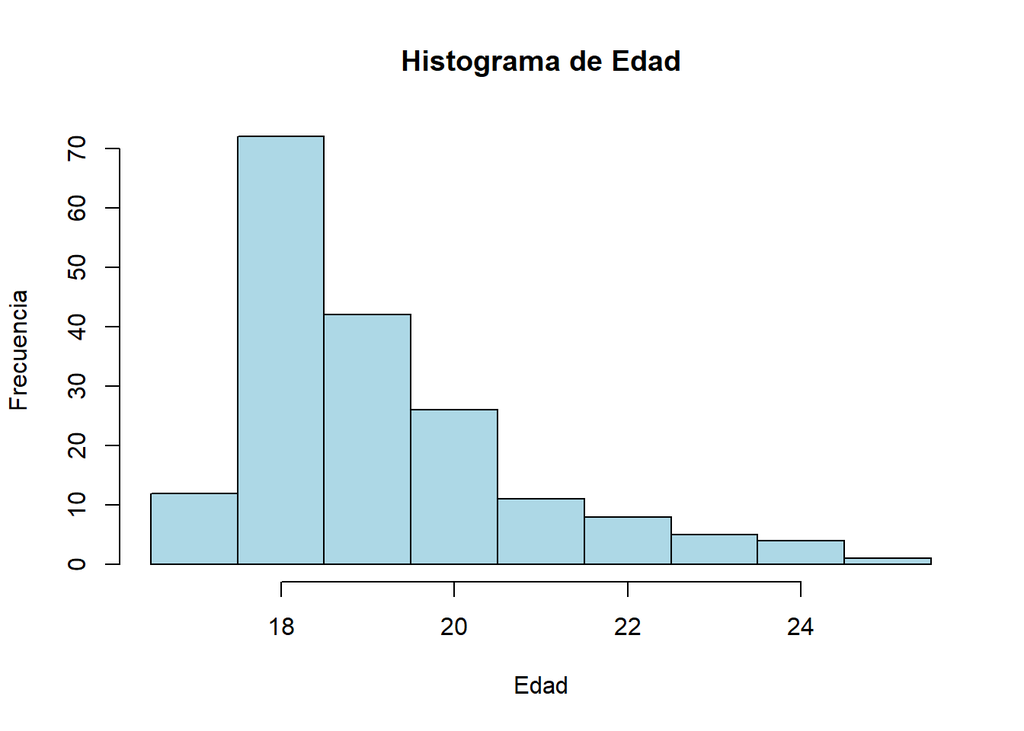

Gracias al diagrama de cajas también podemos ver que existen valores poco representativos para la edad de los alumnos, que son los valores más alejados (24, 25 años).

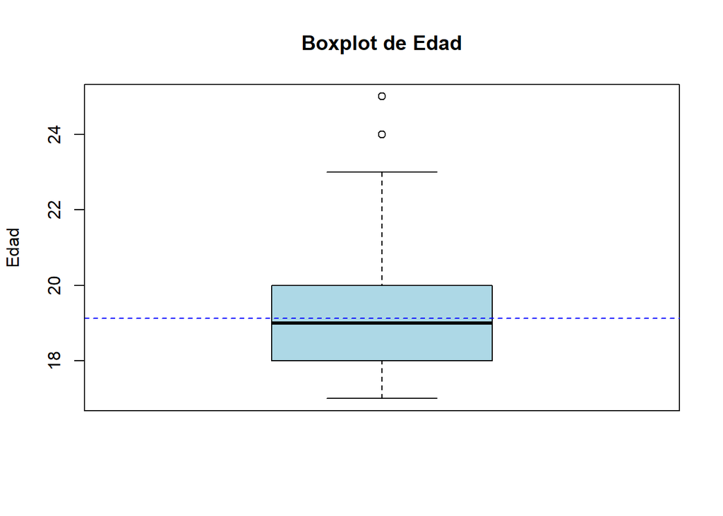

```
## # A tibble: 9 x 2
##   `datosdep$edad`     n
##             <dbl> <int>
## 1              17    12
## 2              18    72
## 3              19    42
## 4              20    26
## 5              21    11
## 6              22     8
## 7              23     5
## 8              24     4
## 9              25     1
```

```
## [1] "Promedio: 19.12"
```

```
## [1] "Mediana: 19"
```

```
## [1] "La moda es: 18"
```

```
## [1] "Rango: 8"
```

```
## [1] "Desviación estándar: 1.63 años"
```

```
## [1] "Coeficiente de variación: 8.53"
```

A partir del análisis y la siguiente tabla podemos concluir:

- La mitad de los encuestados tiene una edad mayor o igual que 19 y la otra mitad, menor que 19 (*mediana*).
- La mayor parte de encuestados tiene 18 años de edad. El gráfico también nos indica que media mediana y moda se encuentran alrededor del mismo valor aproximadamente, por lo que las edades de los estudiantes de UTEC tienden a estar agrupados cerca de su media.
- Tenemos un coeficiente de variación bajo (de 8.52) que nos indica una dispersión baja, y por consiguiente, datos relativamente homogéneos.

#### 3.1.0.2 Peso (kg):

Con el siguiente gráfico podemos saber que la mayor parte de los encuestados posee un peso entre 60 y 70kg.

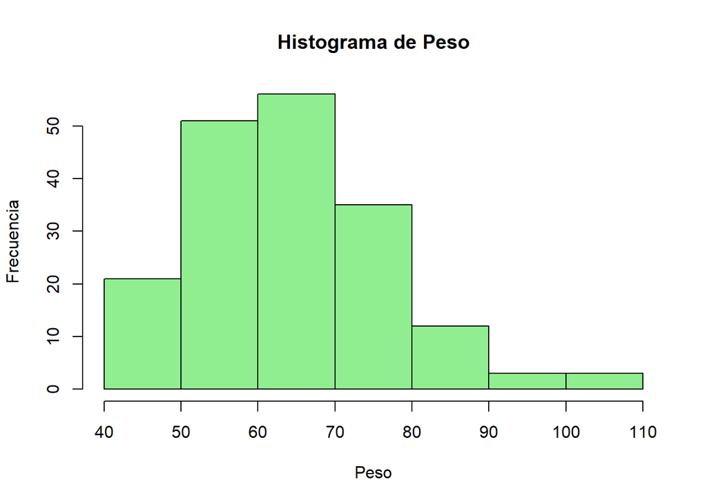

Gracias al diagrama de cajas podemos observar que, en comparación a la edad, hay más valores poco representativos (pesos que sobrepasan los 90kg).

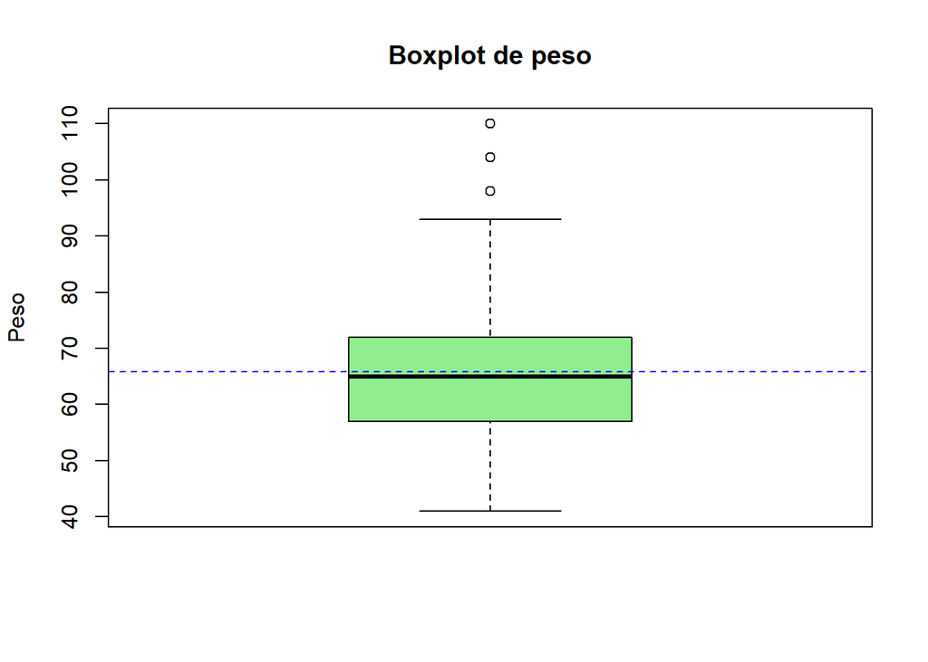

```
## # A tibble: 55 x 2
##    `datosdep$peso`     n
##              <dbl> <int>
##  1            41       2
##  2            45       2
##  3            47       2
##  4            48       5
##  5            49       2
##  6            50       8
##  7            50.5     1
##  8            51       1
##  9            52       1
## 10            53       2
## # i 45 more rows
```

```
## [1] "El peso promedio es de 65.78 kg."
```

```
## [1] "La mediana es 65"
```

```
## [1] "La moda es 70"
```

```
## [1] "Rango: 69"
```

```
## [1] "Desviacion estándar:  12.42 kg"
```

```
## [1] "Coeficiente de variación: 18.88"
```

A partir del análisis, los valores de los descriptores y la siguiente tabla podemos mostrar lo siguiente:

- La mayor parte de los encuestados posee un peso entre 60 y 70kg.
- El gráfico nos muestra que media, mediana y moda se encuentran alrededor del mismo valor.
- Tenemos un coeficiente de variación más alto que el anterior (de 18.88) que nos indica una dispersión más alta, y por consiguiente, datos más dispersos. Es normal considerando que estamos hablando de pesos.

#### 3.1.0.3 Estatura (m):

El histograma nos indica que la mayor parte de los encuestados posee una altura entre 1.65 y 1.70 metros

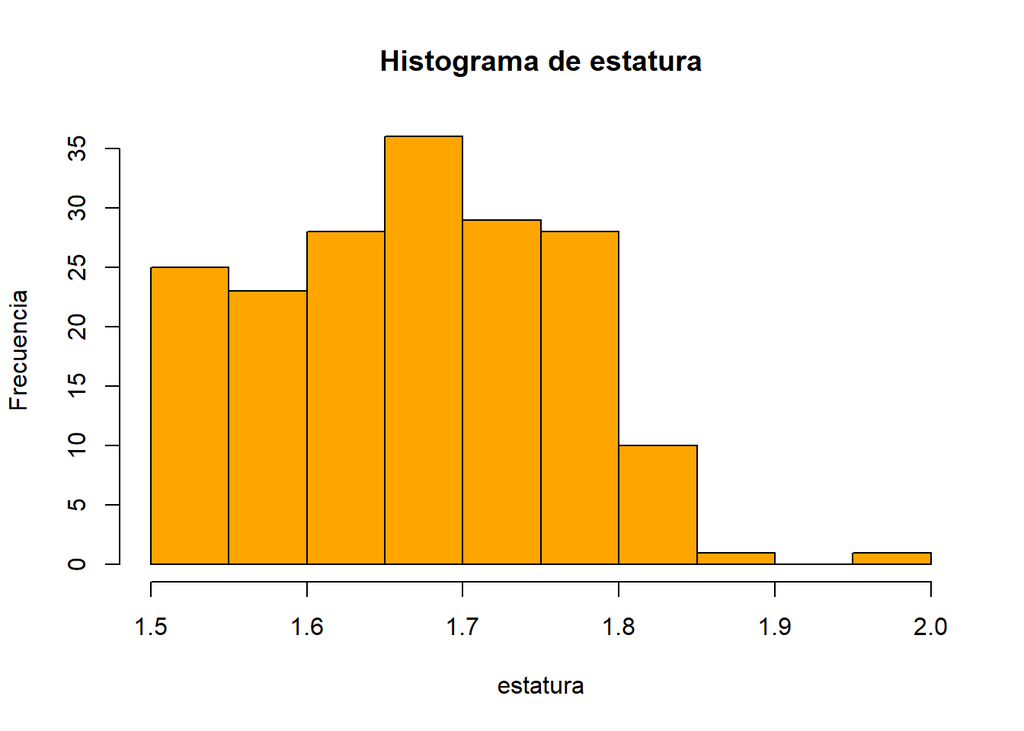

Gracias al diagrama de cajas podemos observar que promedio, mediana y moda no presentan una asimetría significativa.

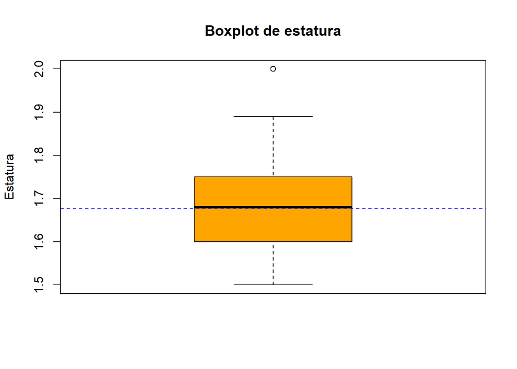

```
## # A tibble: 37 x 2
##    `datosdep$estatura`     n
##                  <dbl> <int>
##  1                1.5      5
##  2                1.51     1
##  3                1.52     3
##  4                1.53     3
##  5                1.54     6
##  6                1.55     7
##  7                1.56     5
##  8                1.57     2
##  9                1.58     3
## 10                1.59     2
## # i 27 more rows
```

```
## [1] "Promedio: 1.68"
```

```
## [1] "Mediana: 1.68"
```

```
## [1] "La moda es: 1.7"
```

```
## [1] "Rango: 0.5"
```

```
## [1] "Desviación estándar: 0.1 m"
```

```
## [1] "Coeficiente de variación: 5.95"
```

#### 3.1.0.4 Alimentación principal.

Conoceremos los hábitos alimenticios de los estudiantes de UTEC.

Determinamos que por amplia mayoría, los encuestados comen principalmente alimentos no procesados.

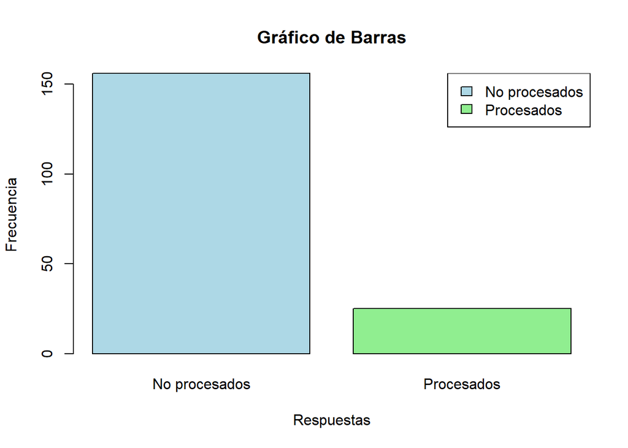

Aquí se concluye que la gran mayoría de los encuestados tiende a comer alimentos no procesados, lo cual indicaría una señal de una alimentción responsable y/o saludable.

#### 3.1.0.5 Tipos de alimentación

De los encuestados podemos determinar las siguientes cosas:

Respecto a las proteínas, es la categoría de alimentos más consumida por semana en los estudiantes.

```
## # A tibble: 7 x 2
##   `datosdep$proteinas`     n
##   <chr>                <int>
## 1 0 veces por semana      25
## 2 2 veces por semana       6
## 3 3 veces por semana      16
## 4 4 veces por semana      19
## 5 5 veces por semana      38
## 6 6 veces por semana      30
## 7 7 veces por semana      47
```

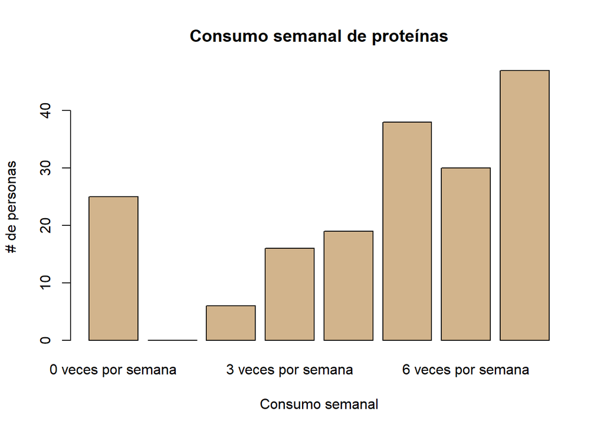

Las frutas y verduras son mayormente consumidas 5 veces por semana.

```
## # A tibble: 8 x 2
##   `datosdep$veg_frut`     n
##   <chr>               <int>
## 1 0 veces por semana     25
## 2 1 vez por semana        6
## 3 2 veces por semana      8
## 4 3 veces por semana     16
## 5 4 veces por semana     22
## 6 5 veces por semana     45
## 7 6 veces por semana     22
## 8 7 veces por semana     37
```

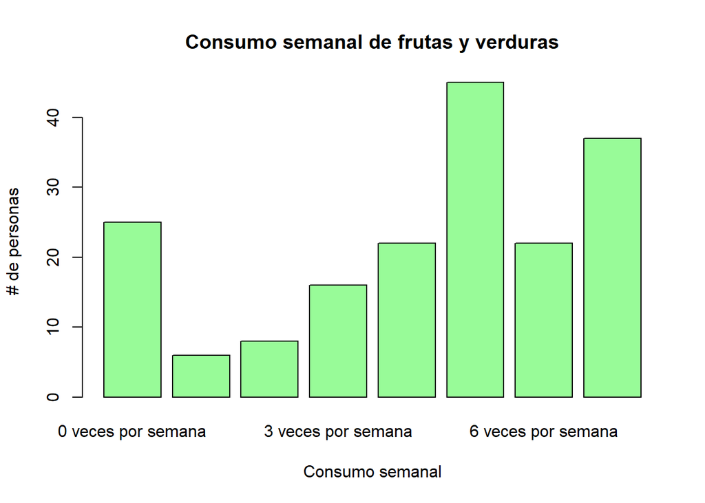

Las grasas no son de consumo tan frecuente como las otras categorías. Son consumidas 3 veces por semana.

```
## # A tibble: 8 x 2
##   `datosdep$gras_aceit`     n
##   <chr>                 <int>
## 1 0 veces por semana       25
## 2 1 vez por semana          9
## 3 2 veces por semana       19
## 4 3 veces por semana       35
## 5 4 veces por semana       23
## 6 5 veces por semana       33
## 7 6 veces por semana       21
## 8 7 veces por semana       16
```

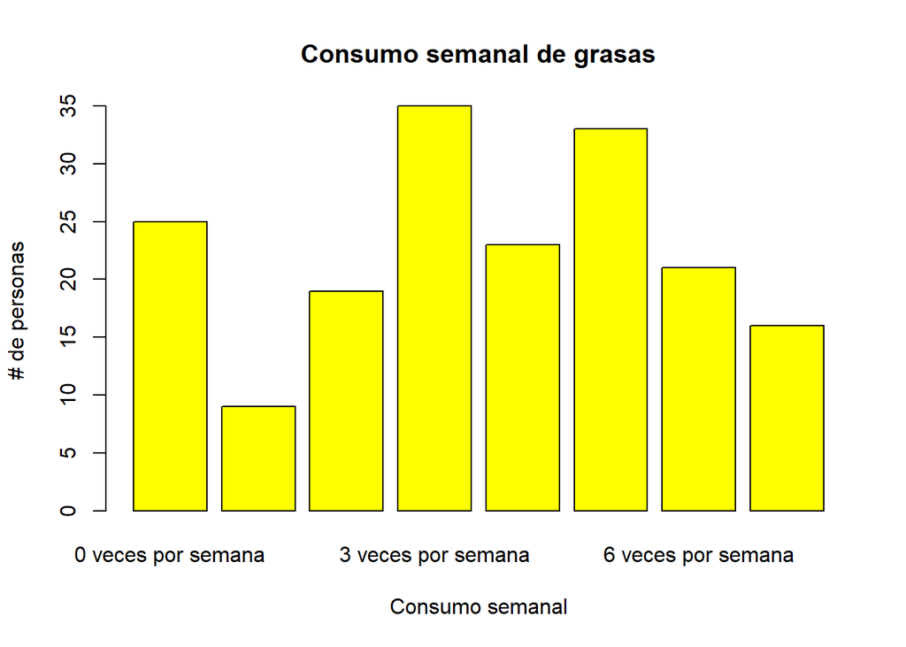

Los lácteos son mayormente consumidos 5 veces por semana.

```
## # A tibble: 8 x 2
##   `datosdep$lacteos`     n
##   <chr>              <int>
## 1 0 veces por semana    25
## 2 1 vez por semana       7
## 3 2 veces por semana    23
## 4 3 veces por semana    22
## 5 4 veces por semana    23
## 6 5 veces por semana    39
## 7 6 veces por semana    22
## 8 7 veces por semana    20
```

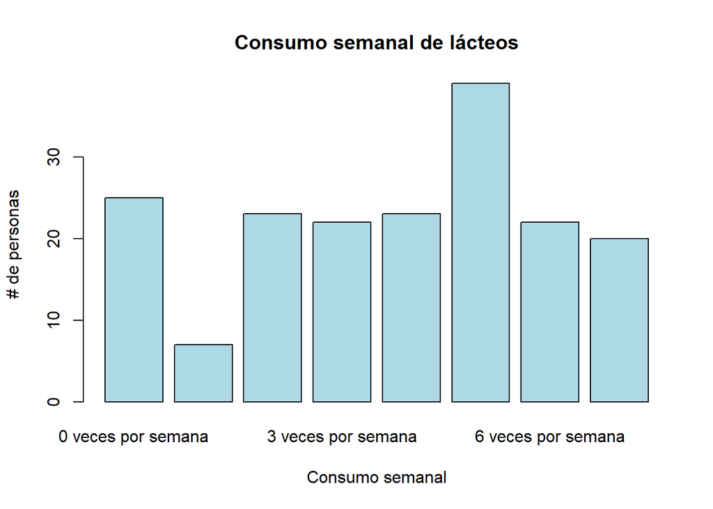

Los cereales si son frecuentemente consumidos. Muchos de los encuestados suelen comer cereales entre 5 a 7 veces por semana.

```
## # A tibble: 8 x 2
##   `datosdep$cere_gran`     n
##   <chr>                <int>
## 1 0 veces por semana      25
## 2 1 vez por semana         2
## 3 2 veces por semana       4
## 4 3 veces por semana      17
## 5 4 veces por semana      25
## 6 5 veces por semana      35
## 7 6 veces por semana      38
## 8 7 veces por semana      35
```

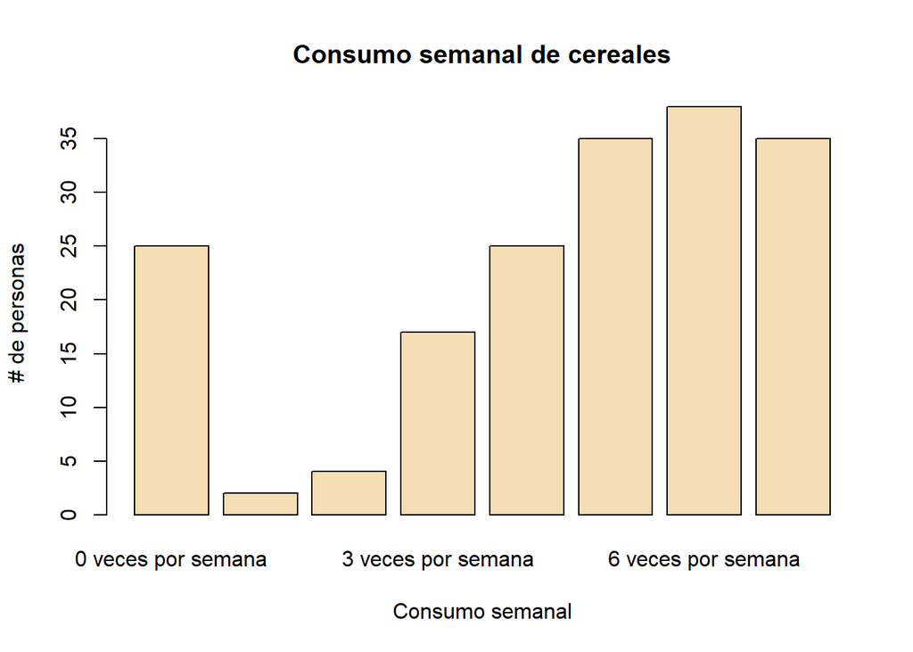

Los azúcares tienen un consumo frecuente, de 5 veces por semana en los alumnos de UTEC.

```
## # A tibble: 8 x 2
##   `datosdep$azuc_dul`     n
##   <chr>               <int>
## 1 0 veces por semana     25
## 2 1 vez por semana       15
## 3 2 veces por semana     18
## 4 3 veces por semana     30
## 5 4 veces por semana     28
## 6 5 veces por semana     32
## 7 6 veces por semana     22
## 8 7 veces por semana     11
```

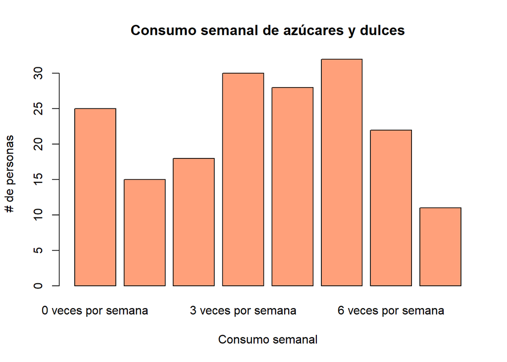

#### 3.1.0.6 Actividad Física

Conoceremos la afición de los estudiantes de UTEC por la actividad física.

La cantidad de estudiantes que realizan actividad física, sobrepasa por muy poco a la cantidad de estudiantes que no se ejercita con frecuencia. Podría ser una mala señal en la salud de los estudiantes a futuro.

```
## # A tibble: 2 x 2
##   `datosdep$act_fisica`     n
##   <chr>                 <int>
## 1 No                       85
## 2 Sí                       96
```

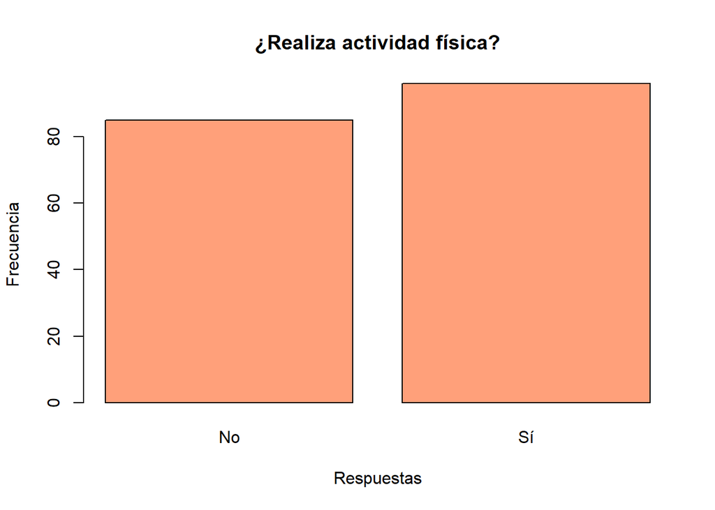

Como podemos observar a través de las tablas, el deporte más realizado es el de “Gimnasio/Calistenia/Crossfit”

```
## # A tibble: 25 x 2
##    tipo_act                            n
##    <chr>                           <int>
##  1 "No ejercita"                      85
##  2 "Fútbol"                           36
##  3 "Gimnasio/Calistenia/Crossfit"     20
##  4 " Gimnasio/Calistenia/Crossfit"    18
##  5 " Ciclismo"                        13
##  6 " Running"                         13
##  7 " Natación"                         9
##  8 "Natación"                          9
##  9 " Artes Marciales"                  8
## 10 " Básquet"                          6
## # i 15 more rows
```

Podemos observar en esta tabla, que sin importar el deporte que se practique, los encuestados que se ejercitan con frecuencia, en su mayoría suelen entrenar 2/3 veces por semana.

```
## # A tibble: 5 x 2
##   `datosdep$frec_act`      n
##   <chr>                <int>
## 1 1 vez por semana        16
## 2 2/3 veces por semana    42
## 3 4/5 veces por semana    32
## 4 6/7 veces por semana     6
## 5 No ejercita             85
```

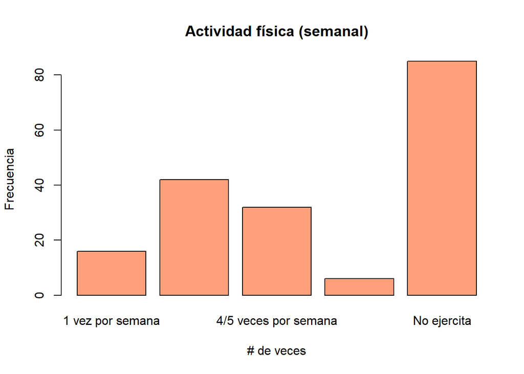

En esta tabla se observan los tiempos en segundos por día que le dedican las personas a su actividad física.

```
## # A tibble: 20 x 2
##    `datosdep$tiem_act`     n
##                  <dbl> <int>
##  1                   0    85
##  2                1200     2
##  3                1800     3
##  4                2400     3
##  5                2700     1
##  6                3600    24
##  7                3661     1
##  8                4800     2
##  9                4803     1
## 10                5400    14
## 11                7200    27
## 12                8400     1
## 13                9000     4
## 14                9001     1
## 15               10200     1
## 16               10201     1
## 17               10800     5
## 18               14400     3
## 19               16200     1
## 20               18000     1
```

Quitamos de consideración a los que no ejercitan

```
## # A tibble: 96 x 1
##    NewTiem_act
##          <dbl>
##  1        7200
##  2        5400
##  3        7200
##  4        7200
##  5        9000
##  6       14400
##  7        7200
##  8        3600
##  9        8400
## 10        3600
## # i 86 more rows
```

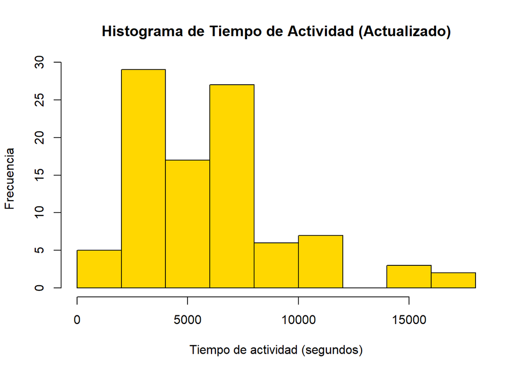

Descriptores numéricos:

```
## # A tibble: 19 x 2
##    NewTiem_act     n
##          <dbl> <int>
##  1        1200     2
##  2        1800     3
##  3        2400     3
##  4        2700     1
##  5        3600    24
##  6        3661     1
##  7        4800     2
##  8        4803     1
##  9        5400    14
## 10        7200    27
## 11        8400     1
## 12        9000     4
## 13        9001     1
## 14       10200     1
## 15       10201     1
## 16       10800     5
## 17       14400     3
## 18       16200     1
## 19       18000     1
```

```
## [1] "Promedio: 6222.56"
```

```
## [1] "Mediana: 5400"
```

```
## [1] "La moda es: 7200"
```

```
## [1] "Rango: 16800"
```

```
## [1] "Desviación estándar: 3239.45 seg"
```

```
## [1] "Coeficiente de variación: 52.06"
```

Con ellos podemos determinar:

El boxplot nos indica que hay datos no representativos que se alejan bastante de los valores representativos.

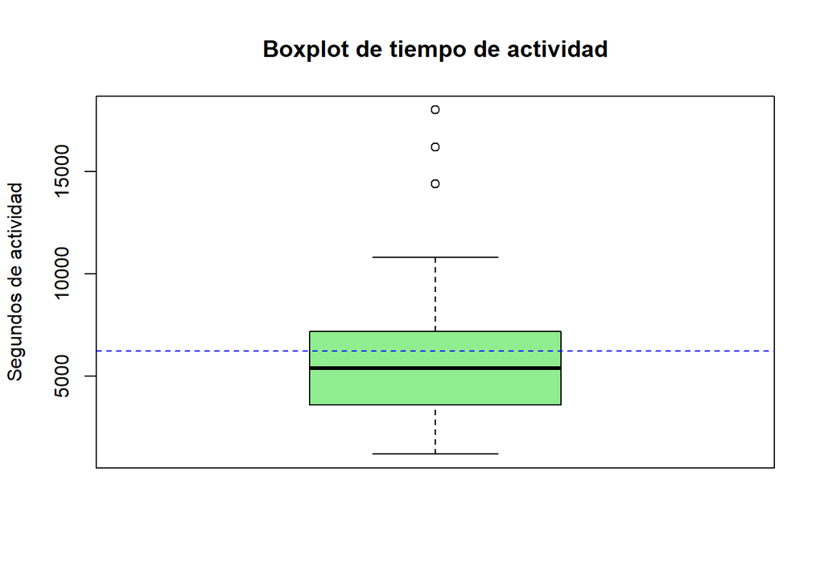

#### 3.1.0.7 Ciclo

La siguiente tabla nos muestra como la mayor parte de los encuestados pertenece al tercer ciclo

```
## # A tibble: 10 x 2
##    ciclo             n
##    <fct>         <dbl>
##  1 Primer Ciclo      4
##  2 Segundo Ciclo    50
##  3 Tercer Ciclo     67
##  4 Cuarto Ciclo     30
##  5 Quinto Ciclo     11
##  6 Sexto Ciclo       3
##  7 Séptimo Ciclo     6
##  8 Octavo Ciclo      1
##  9 Noveno Ciclo      4
## 10 Décimo Ciclo      5
```

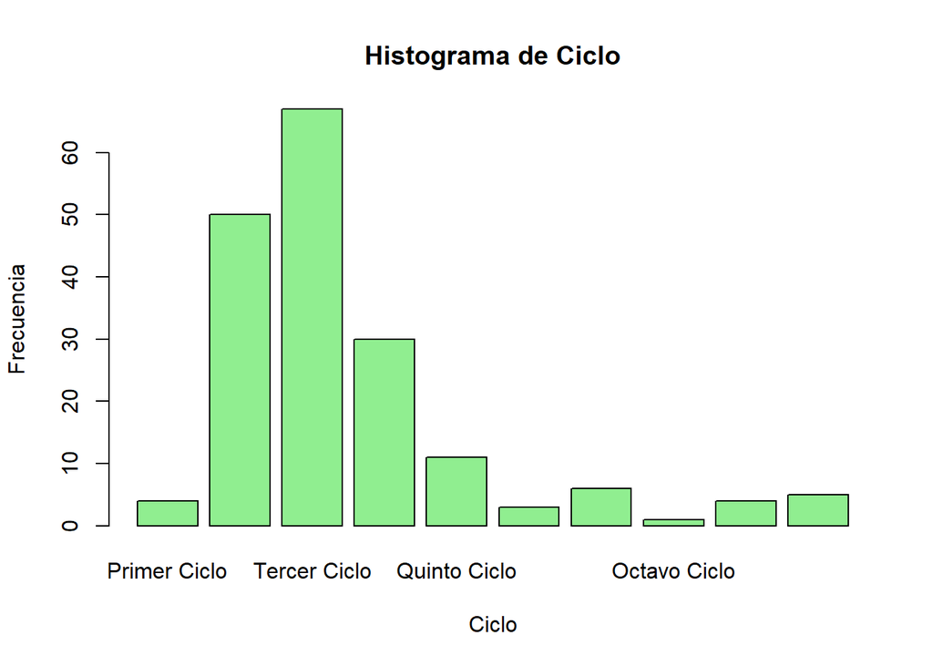

#### 3.1.0.8 Clasificación

```
## # A tibble: 5 x 2
##   `datosdep$clasificacion`        n
##   <chr>                       <int>
## 1 1.Décimo superior              31
## 2 2.Quinto superior              27
## 3 3.Tercio superior              52
## 4 4.Medio superior               37
## 5 5.Ninguno de los anteriores    34
```

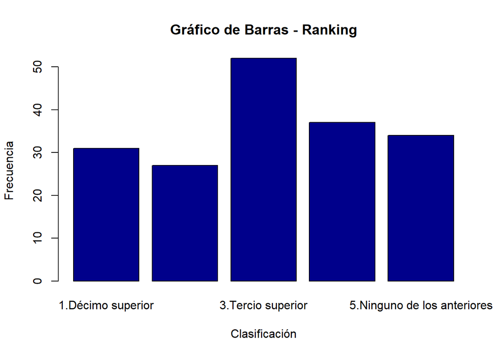

## 3.2 Relaciones entre variables

Analizaremos las relaciones entre las variables que conciernen a nuestro estudio estadístico

#### 3.2.0.1 Relación Peso-Altura

La relación peso estatura es parte de una medida común en la medicina que sirve para guiarse a la hora de determinar el peso saludable de una persona, el IMC. Como podemos ver, existe una correlación de 0.65, un indicio de que tiene un grado considerable de linealidad. A medida que crecemos en estatura, usualmente creceremos en peso también.

```
## [1] "Grado de correlación: 0.65"
```

Determinamos el diagrama de dispersión de estas dos variables y como podemos ver, a simple vista pareciera que tienden a formar una línea recta dispersada.

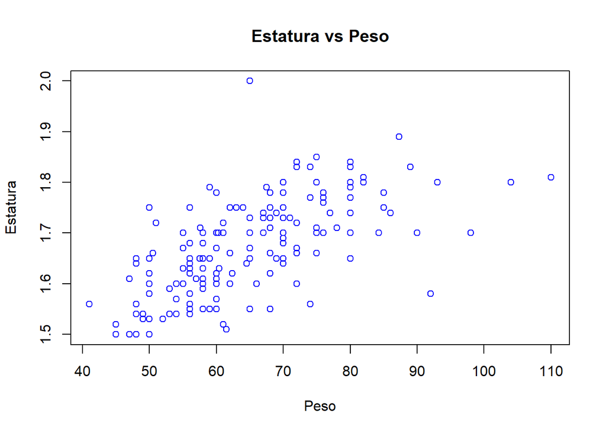

#### 3.2.0.2 Relación Peso-Alimentación principal

Como podemos observar, las personas que consumen principalmente alimentos no procesados poseen una concentración de población que va desde los 56 kilos hasta los 73 kilos aprox. A pesar de que ellos tengan unos datos no representativos mayores a los que consumen principalmente alimentos procesados, estos últimos poseen un margen superior al anterior y más amplio, parten de los 58/59 kilos hasta los 80.

A su vez, podemos ver como los que consumen alimentos no procesados poseen un sesgo hacia la izquierda, por lo que su promedio es menor que la mediana. Estas características, también las posee la población que consume alimentos procesados.

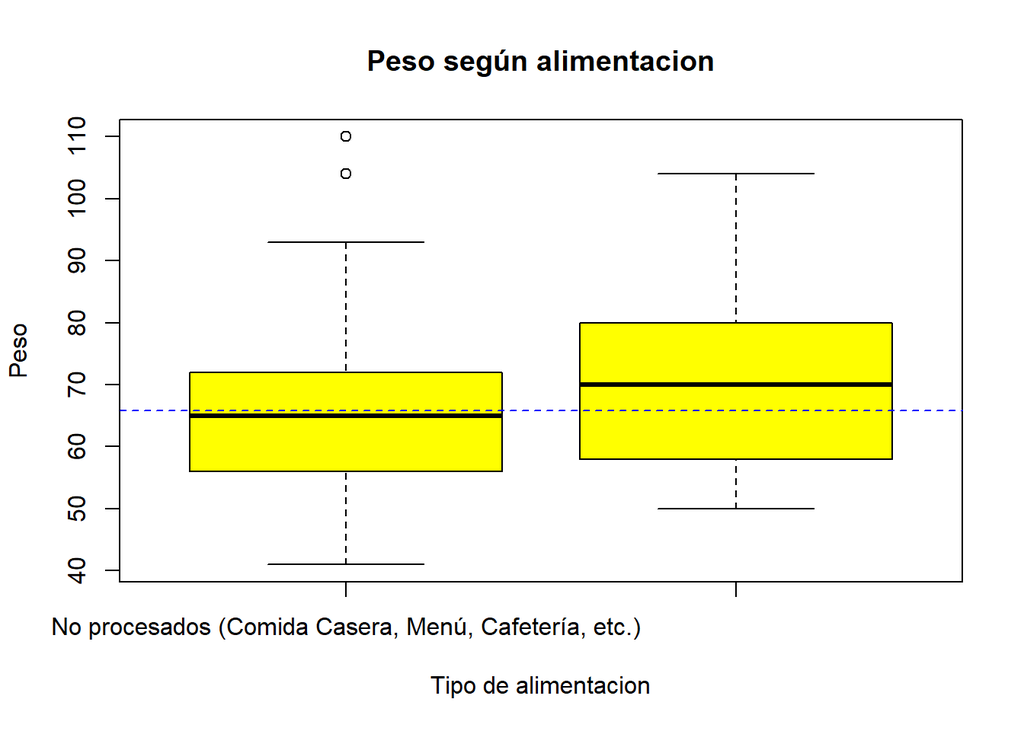

#### 3.2.0.3 Relación Ranking-Actividad Física

Como se puede observar en el décimo superior, está dividida casi a la mitad la cantidad de estudiantes que hace ejercicio con quienes no. Del quinto al al medio superior, los estudiantes que hacen ejercicio sobrepasan a los que no lo hacen. Dentro de los últimos en el ranking, también parece que están divididos por la mitad, o incluso pareciera que los que no hacen ejercicio superan a los que sí. Entonces se puede notar que mientras un estudiante sí practique ejercicio, es más probable que se encuentre al menos dentro de los 3 últimos rangos de clasificación. Bajo esa observación, podríamos deducir una relación positiva entre el ejercicio y el estudio. Sin embargo, en cuanto al primer rango de clasificación, podemos deducir incluso una relación negativa entre ejercicio y estudio. Esto se puede deber a que una inversión de tiempo en actividad física quita tiempo en lo que respecta para enfocarse más al aspecto académico. Podríamos interpretar lo mismo en cuanto a los estudiantes que no pertenecen a ningún rango, pero como algunos de ellos son de primer ciclo y no están clasificados, no podemos establecer ninguna relación.

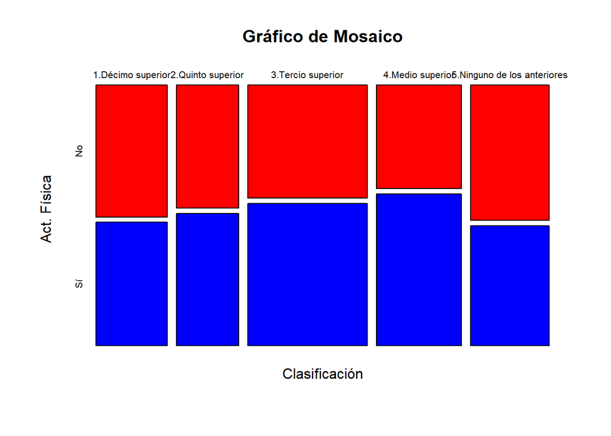

#### 3.2.0.4 Relación Alimentación Principal-Ranking

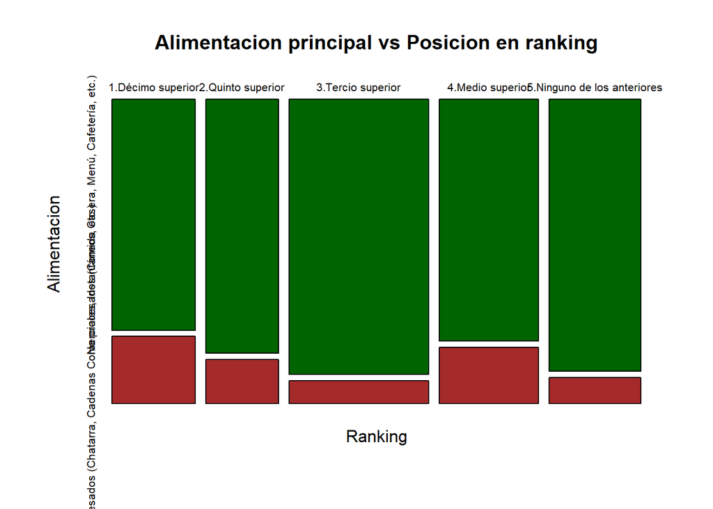